# Homework 3-1

Nithin Mahesh

### Linear regression

#### Part 1: Simple regression

Are Midterm grades predictive of FinalExam grades? This part asks you to fit a linear regression model to the data.

Q1(2pts): Read in the Grades.tsv data file with the read.table function and assign the output to the variable “df.grades”.

```r
df.grades<-read.table("Grades.tsv", header = TRUE)
```

Q2(5pts): Plot the data in a scatter plot with the final exam on the y axis and the midterm on the x axis.

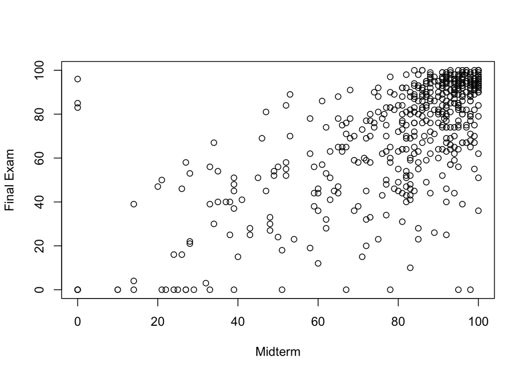

```r
plot(x=df.grades$Midterm, y=df.grades$FinalExam, ylab="Final Exam", xlab = "Midterm")
```

Q3(4pts): Fit a linear model to the data with the midterm as covariate and final exam as the response variable. Display the output of the fit with the summary function.

```r
fit <- lm(FinalExam ~ Midterm, data=df.grades)
summary(fit)
```

```
##
## Call:
## lm(formula = FinalExam ~ Midterm, data = df.grades)
##
## Residuals:
##     Min      1Q  Median      3Q     Max
## -86.139  -9.484   4.796  11.983  90.262
##
## Coefficients:
##             Estimate Std. Error t value Pr(>|t|)
## (Intercept)  5.73760    3.11149   1.844   0.0658 .
## Midterm      0.82042    0.03736  21.960   <2e-16 ***
## ---
## Signif. codes:  0 '***' 0.001 '**' 0.01 '*' 0.05 '.' 0.1 ' ' 1
##
## Residual standard error: 19.07 on 518 degrees of freedom
## Multiple R-squared:  0.4821, Adjusted R-squared:  0.4811
## F-statistic: 482.2 on 1 and 518 DF,  p-value: < 2.2e-16
```

Q4(8pts): Plot the data again with the regression line. Title the axes “Midterm” and “Final Exam” respectively.

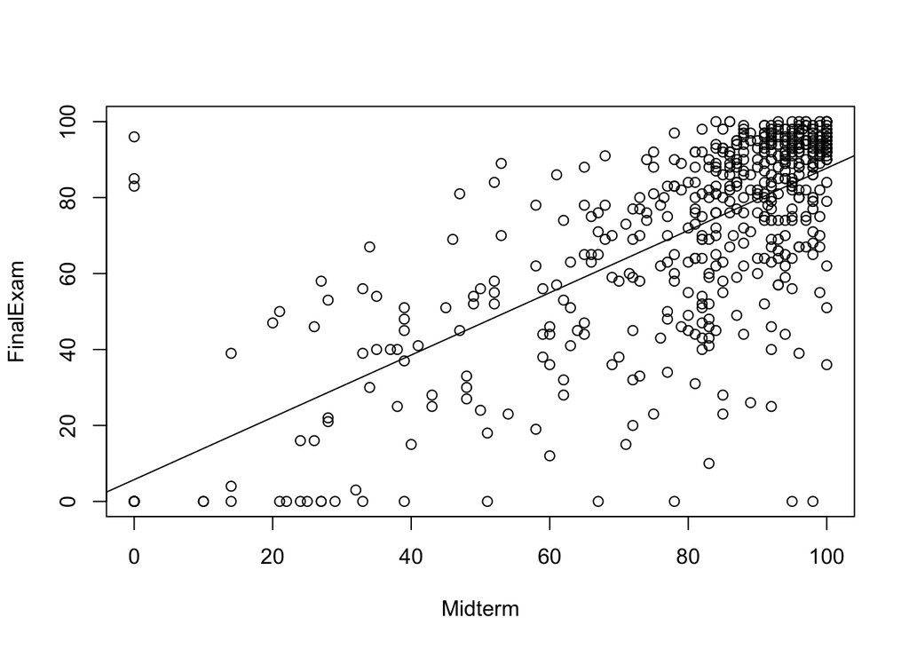

```r
plot(FinalExam ~ Midterm, data=df.grades)
abline(coef(fit), lty=1)
```

Q5(8pts): Plot the residuals against the data (the Midterm column). Does this suggest and problems with the model?

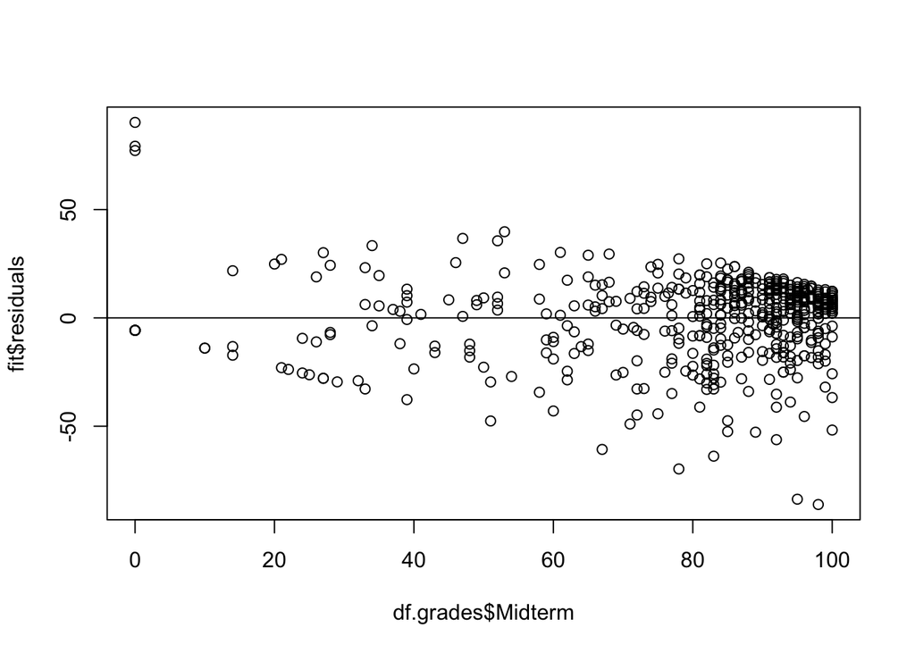

```r
plot(df.grades$Midterm, fit$residuals)
abline(h=0)
```

## # Yes there is a problem since the residuals are more clustered towards the larger fitted numbers.

Q6(10pts): In your opinion, is the model a good fit to the data? What percent of the variance is explained by the model? What is the overall accuracy of the model?

# In my opinion the model is a fairly good fit to the data, it follows the normal distribution to an extent. However, it is a limited data set as values cannot fall below 0 or exceed 100 and many students scored closer to 100 so there is not a large amount of variance. The overall accuracy of the model is about 80%, for every point students scored correctly on the midterm, they would score .8 correctly on the final or in other terms if students got 10 questions correct on the midterm they would get 8 correct on the final. The model is off by about 19 points. This is quite high for a spread of 0 to 100.

Q7(8pts): Predict the final exam grade from a midterm grade of 88. Use a 95% prediction interval.

```r
attributes(fit)
```

```
## $names
##  [1] "coefficients"  "residuals"     "effects"       "rank"
##  [5] "fitted.values" "assign"        "qr"            "df.residual"
##  [9] "xlevels"       "call"          "terms"         "model"
##
## $class
## [1] "lm"
```

```r
intercept <- fit$coefficients[[1]]
param <- fit$coefficients[[2]]
newdata = data.frame(score=88)
colnames(newdata) <- c("Midterm")
predict(fit, newdata, interval="predict")
```

```
##        fit      lwr      upr
## 1 77.93464 40.42842 115.4409
```

Q8(15pts): Select a subset of the data for Midterm scores of 88 and show the summary statistics of the final exam scores for that subset. How does your prediction match the data?

```r
fullsum <- subset(df.grades, Midterm > 88)
summary(fullsum)
```

```
##     Midterm         FinalExam      Grade
##  Min.   : 89.00   Min.   :  0.00   A:154
##  1st Qu.: 92.00   1st Qu.: 80.00   B: 59
##  Median : 95.00   Median : 91.00   C: 29
##  Mean   : 95.35   Mean   : 85.15   D:  5
##  3rd Qu.: 98.00   3rd Qu.: 95.00   F:  4
##  Max.   :100.00   Max.   :100.00
```

| # My prediction matches the data fairly accurately. |
| --- |